# Sales Data Analysis Project

### Importing the dataset

```python
import pandas as pd
data = pd.read_excel('Sales_data.xlsx')
```

```python
data.info()
```

```
<class 'pandas.core.frame.DataFrame'>
RangeIndex: 51290 entries, 0 to 51289
Data columns (total 24 columns):
 #   Column          Non-Null Count  Dtype
---  ------          --------------  -----
 0   Row ID          51290 non-null  int64
 1   Order ID        51290 non-null  object
 2   Order Date      51290 non-null  datetime64[ns]
 3   Ship Date       51290 non-null  datetime64[ns]
 4   Ship Mode       51290 non-null  object
 5   Customer ID     51290 non-null  object
 6   Customer Name   51290 non-null  object
 7   Segment         51290 non-null  object
 8   City            51290 non-null  object
 9   State           51290 non-null  object
```

[output cut: 16 more lines]

```python
data.describe()
```

|  | Row ID | Postal Code | Sales | Quantity | Discount | Profit | Shipping Cost |
| --- | --- | --- | --- | --- | --- | --- | --- |
| count | 51290.00 | 9994.00 | 51290.00 | 51290.00 | 51290.00 | 51290.00 | 51290.00 |
| mean | 25645.50 | 55190.38 | 246.49 | 3.48 | 0.14 | 28.61 | 26.38 |
| std | 14806.29 | 32063.69 | 487.57 | 2.28 | 0.21 | 174.34 | 57.30 |
| min | 1.00 | 1040.00 | 0.44 | 1.00 | 0.00 | -6599.98 | 0.00 |
| 25% | 12823.25 | 23223.00 | 30.76 | 2.00 | 0.00 | 0.00 | 2.61 |
| 50% | 25645.50 | 56430.50 | 85.05 | 3.00 | 0.00 | 9.24 | 7.79 |
| 75% | 38467.75 | 90008.00 | 251.05 | 5.00 | 0.20 | 36.81 | 24.45 |
| max | 51290.00 | 99301.00 | 22638.48 | 14.00 | 0.85 | 8399.98 | 933.57 |

### Cleaning the Dataset

```python
data['Postal Code'] = data['Postal Code'].astype('object')
data['Order ID'] = data['Order ID'].astype('object')
data['Customer ID'] = data['Customer ID'].astype('object')
```

```python
data.info()
```

```
<class 'pandas.core.frame.DataFrame'>
RangeIndex: 51290 entries, 0 to 51289
Data columns (total 24 columns):
 #   Column          Non-Null Count  Dtype
---  ------          --------------  -----
 0   Row ID          51290 non-null  int64
 1   Order ID        51290 non-null  object
 2   Order Date      51290 non-null  datetime64[ns]
 3   Ship Date       51290 non-null  datetime64[ns]
 4   Ship Mode       51290 non-null  object
 5   Customer ID     51290 non-null  object
 6   Customer Name   51290 non-null  object
 7   Segment         51290 non-null  object
 8   City            51290 non-null  object
 9   State           51290 non-null  object
```

[output cut: 16 more lines]

```python
data.drop_duplicates(inplace=True)
```

```python
data.info()
```

```
<class 'pandas.core.frame.DataFrame'>
Int64Index: 51290 entries, 0 to 51289
Data columns (total 24 columns):
 #   Column          Non-Null Count  Dtype
---  ------          --------------  -----
 0   Row ID          51290 non-null  int64
 1   Order ID        51290 non-null  object
 2   Order Date      51290 non-null  datetime64[ns]
 3   Ship Date       51290 non-null  datetime64[ns]
 4   Ship Mode       51290 non-null  object
 5   Customer ID     51290 non-null  object
 6   Customer Name   51290 non-null  object
 7   Segment         51290 non-null  object
 8   City            51290 non-null  object
 9   State           51290 non-null  object
```

[output cut: 16 more lines]

```python
data.head()
```

|  | Row ID | Order ID | Order Date | Ship Date | Ship Mode | Customer ID | Customer Name | Segment | City | State | ... | Product ID | Category | Sub-Category | Product Name | Sales | Quantity | Discount | Profit | Shipping Cost | Order Priority |
| --- | --- | --- | --- | --- | --- | --- | --- | --- | --- | --- | --- | --- | --- | --- | --- | --- | --- | --- | --- | --- | --- |
| 0 | 32298 | CA-2012-124891 | 2012-07-31 | 2012-07-31 | Same Day | RH-19495 | Rick Hansen | Consumer | New York City | New York | ... | TEC-AC-10003033 | Technology | Accessories | Plantronics CS510 - Over-the-Head monaural Wir... | 2309.65 | 7 | 0.00 | 762.18 | 933.57 | Critical |
| 1 | 26341 | IN-2013-77878 | 2013-02-05 | 2013-02-07 | Second Class | JR-16210 | Justin Ritter | Corporate | Wollongong | New South Wales | ... | FUR-CH-10003950 | Furniture | Chairs | Novimex Executive Leather Armchair, Black | 3709.39 | 9 | 0.10 | -288.76 | 923.63 | Critical |
| 2 | 25330 | IN-2013-71249 | 2013-10-17 | 2013-10-18 | First Class | CR-12730 | Craig Reiter | Consumer | Brisbane | Queensland | ... | TEC-PH-10004664 | Technology | Phones | Nokia Smart Phone, with Caller ID | 5175.17 | 9 | 0.10 | 919.97 | 915.49 | Medium |
| 3 | 13524 | ES-2013-1579342 | 2013-01-28 | 2013-01-30 | First Class | KM-16375 | Katherine Murray | Home Office | Berlin | Berlin | ... | TEC-PH-10004583 | Technology | Phones | Motorola Smart Phone, Cordless | 2892.51 | 5 | 0.10 | -96.54 | 910.16 | Medium |
| 4 | 47221 | SG-2013-4320 | 2013-11-05 | 2013-11-06 | Same Day | RH-9495 | Rick Hansen | Consumer | Dakar | Dakar | ... | TEC-SHA-10000501 | Technology | Copiers | Sharp Wireless Fax, High-Speed | 2832.96 | 8 | 0.00 | 311.52 | 903.04 | Critical |

5 rows × 24 columns

### Data Preparation

```python
total_sales = data['Sales'].sum()
average_sales = data['Sales'].mean()

data['month_year'] = data['Order Date'].dt.to_period('M')
monthly_sales = data.groupby('month_year')['Sales'].sum()
```

```python
data.head()
```

|  | Row ID | Order ID | Order Date | Ship Date | Ship Mode | Customer ID | Customer Name | Segment | City | State | ... | Category | Sub-Category | Product Name | Sales | Quantity | Discount | Profit | Shipping Cost | Order Priority | month_year |
| --- | --- | --- | --- | --- | --- | --- | --- | --- | --- | --- | --- | --- | --- | --- | --- | --- | --- | --- | --- | --- | --- |
| 0 | 32298 | CA-2012-124891 | 2012-07-31 | 2012-07-31 | Same Day | RH-19495 | Rick Hansen | Consumer | New York City | New York | ... | Technology | Accessories | Plantronics CS510 - Over-the-Head monaural Wir... | 2309.65 | 7 | 0.00 | 762.18 | 933.57 | Critical | 2012-07 |
| 1 | 26341 | IN-2013-77878 | 2013-02-05 | 2013-02-07 | Second Class | JR-16210 | Justin Ritter | Corporate | Wollongong | New South Wales | ... | Furniture | Chairs | Novimex Executive Leather Armchair, Black | 3709.39 | 9 | 0.10 | -288.76 | 923.63 | Critical | 2013-02 |
| 2 | 25330 | IN-2013-71249 | 2013-10-17 | 2013-10-18 | First Class | CR-12730 | Craig Reiter | Consumer | Brisbane | Queensland | ... | Technology | Phones | Nokia Smart Phone, with Caller ID | 5175.17 | 9 | 0.10 | 919.97 | 915.49 | Medium | 2013-10 |
| 3 | 13524 | ES-2013-1579342 | 2013-01-28 | 2013-01-30 | First Class | KM-16375 | Katherine Murray | Home Office | Berlin | Berlin | ... | Technology | Phones | Motorola Smart Phone, Cordless | 2892.51 | 5 | 0.10 | -96.54 | 910.16 | Medium | 2013-01 |
| 4 | 47221 | SG-2013-4320 | 2013-11-05 | 2013-11-06 | Same Day | RH-9495 | Rick Hansen | Consumer | Dakar | Dakar | ... | Technology | Copiers | Sharp Wireless Fax, High-Speed | 2832.96 | 8 | 0.00 | 311.52 | 903.04 | Critical | 2013-11 |

5 rows × 25 columns

```python
monthly_sales
```

```
month_year
2011-01    98898.49
2011-02    91152.16
2011-03   145729.37
2011-04   116915.76
2011-05   146747.84
2011-06   215207.38
2011-07   115510.42
2011-08   207581.49
2011-09   290214.46
2011-10   199071.26
2011-11   298496.54
2011-12   333925.73
2012-01   135780.72
2012-02   100510.22
2012-03   163076.77
2012-04   161052.27
2012-05   208364.89
2012-06   256175.70
2012-07   145236.79
2012-08   303142.94
2012-09   289389.17
2012-10   252939.85
2012-11   323512.42
2012-12   338256.97
2013-01   199185.91
2013-02   167239.65
2013-03   198594.03
2013-04   177821.32
2013-05   260498.56
2013-06   396519.61
2013-07   229928.95
2013-08   326488.79
2013-09   376619.25
2013-10   293406.64
2013-11   373989.36
2013-12   405454.38
2014-01   241268.56
2014-02   184837.36
2014-03   263100.77
2014-04   242771.86
2014-05   288401.05
2014-06   401814.06
2014-07   258705.68
2014-08   456619.94
2014-09   481157.24
2014-10   422766.63
2014-11   555279.03
2014-12   503143.69
Freq: M, Name: Sales, dtype: float64
```

## Data Analysis and visualization

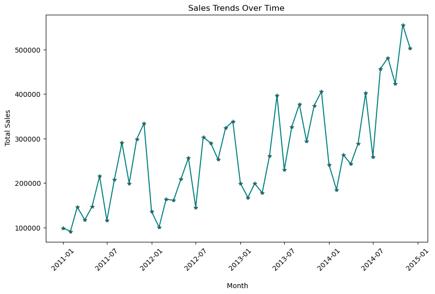

```python
import matplotlib.pyplot as plt
import matplotlib.dates as mdates

plt.figure(figsize=(10, 6))
plt.plot(monthly_sales.index.to_timestamp(), monthly_sales.values, marker='*',color='teal',markerfacecolor='r')
plt.xlabel('\n Month')
plt.xticks(rotation=45)
plt.gca().xaxis.set_tick_params(rotation=45)

plt.ylabel(' Total Sales')
plt.title('Sales Trends Over Time')
plt.show()
```

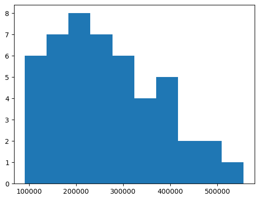

```python
plt.hist(monthly_sales.values, bins=10)
```

```python
best_selling_products = data.groupby('Product Name')['Quantity'].sum().nlargest(10)
```

```python
best_selling_products
```

```
Product Name
Staples                                  876
Cardinal Index Tab, Clear                337
Eldon File Cart, Single Width            321
Rogers File Cart, Single Width           262
Sanford Pencil Sharpener, Water Color    259
Stockwell Paper Clips, Assorted Sizes    253
Avery Index Tab, Clear                   252
Ibico Index Tab, Clear                   251
Smead File Cart, Single Width            250
Stanley Pencil Sharpener, Water Color    242
Name: Quantity, dtype: int64
```

[figure not shown]

```python
plt.bar(best_selling_products.index,best_selling_products.values)
plt.xticks(rotation=90)
plt.xlabel('\n Product Name')
plt.ylabel('Total Quantity Sold')
plt.title('Top 5 Best-Selling Products')
plt.show()
```

### Calculating Average Sales per Sale

```python
total_revenue = data['Sales'].sum()
average_revenue_per_sale = data['Sales'].mean()
```

```python
average_revenue_per_sale
```

```
246.49058120257362
```

```python
revenue_growth_rate = ((monthly_sales[-1] - monthly_sales[-2]) / monthly_sales[-2]) * 100
revenue_growth_rate
```

```
-9.389033438138478
```

*The revenue for the current period has decreased by approximately 9.39% compared to the previous period. This decrease may be attributed to various factors such as seasonality, economic conditions, or changes in consumer behavior.*

```python
sales_by_market = data.groupby('Market')['Sales'].sum().sort_values(ascending=False)
sales_by_region = data.groupby('Region')['Sales'].sum().sort_values(ascending=False)
sales_by_segment = data.groupby('Segment')['Sales'].sum().sort_values(ascending=False)
```

```python
pd.options.display.float_format = '{:.2f}'.format
print(f'{sales_by_market}{sales_by_region} {sales_by_segment}')
```

```
Market
APAC     3585744.13
EU       2938089.06
US       2297200.86
LATAM    2164605.17
EMEA      806161.31
Africa    783773.21
Canada     66928.17
Name: Sales, dtype: float64Region
Central          2822302.52
South            1600907.04
North            1248165.60
Oceania          1100184.61
Southeast Asia    884423.17
North Asia        848309.78
EMEA              806161.31
Africa            783773.21
Central Asia      752826.57
West              725457.82
East              678781.24
Caribbean         324280.86
Canada             66928.17
Name: Sales, dtype: float64 Segment
Consumer      6507949.42
Corporate     3824697.52
Home Office   2309854.97
Name: Sales, dtype: float64
```

```python
data['Profit Margin'] = (data['Profit'] / data['Sales']) * 100
data.head()
```

|  | Row ID | Order ID | Order Date | Ship Date | Ship Mode | Customer ID | Customer Name | Segment | City | State | ... | Sub-Category | Product Name | Sales | Quantity | Discount | Profit | Shipping Cost | Order Priority | month_year | Profit Margin |
| --- | --- | --- | --- | --- | --- | --- | --- | --- | --- | --- | --- | --- | --- | --- | --- | --- | --- | --- | --- | --- | --- |
| 0 | 32298 | CA-2012-124891 | 2012-07-31 | 2012-07-31 | Same Day | RH-19495 | Rick Hansen | Consumer | New York City | New York | ... | Accessories | Plantronics CS510 - Over-the-Head monaural Wir... | 2309.65 | 7 | 0.00 | 762.18 | 933.57 | Critical | 2012-07 | 33.00 |
| 1 | 26341 | IN-2013-77878 | 2013-02-05 | 2013-02-07 | Second Class | JR-16210 | Justin Ritter | Corporate | Wollongong | New South Wales | ... | Chairs | Novimex Executive Leather Armchair, Black | 3709.39 | 9 | 0.10 | -288.76 | 923.63 | Critical | 2013-02 | -7.78 |
| 2 | 25330 | IN-2013-71249 | 2013-10-17 | 2013-10-18 | First Class | CR-12730 | Craig Reiter | Consumer | Brisbane | Queensland | ... | Phones | Nokia Smart Phone, with Caller ID | 5175.17 | 9 | 0.10 | 919.97 | 915.49 | Medium | 2013-10 | 17.78 |
| 3 | 13524 | ES-2013-1579342 | 2013-01-28 | 2013-01-30 | First Class | KM-16375 | Katherine Murray | Home Office | Berlin | Berlin | ... | Phones | Motorola Smart Phone, Cordless | 2892.51 | 5 | 0.10 | -96.54 | 910.16 | Medium | 2013-01 | -3.34 |
| 4 | 47221 | SG-2013-4320 | 2013-11-05 | 2013-11-06 | Same Day | RH-9495 | Rick Hansen | Consumer | Dakar | Dakar | ... | Copiers | Sharp Wireless Fax, High-Speed | 2832.96 | 8 | 0.00 | 311.52 | 903.04 | Critical | 2013-11 | 11.00 |

5 rows × 26 columns

```python
data.to_excel('sales_data_updated.xlsx', index=False)
```

```python
product_profit_sales = data.groupby('Product Name')[['Profit', 'Sales']].sum().reset_index()

product_profit_sales['Profit Margin'] = (product_profit_sales['Profit'] / product_profit_sales['Sales']) * 100

print(product_profit_sales[['Product Name', 'Profit Margin']])
```

```
                                           Product Name  Profit Margin
0     "While you Were Out" Message Book, One Form pe...          41.18
1              #10 Gummed Flap White Envelopes, 100/Box          40.60
2                         #10 Self-Seal White Envelopes          47.96
3            #10 White Business Envelopes,4 1/8 x 9 1/2          45.64
4               #10- 4 1/8" x 9 1/2" Recycled Envelopes          40.21
...                                                 ...            ...
3783  iKross Bluetooth Portable Keyboard + Cell Phon...          24.21
3784                         iOttie HLCRIO102 Car Mount          -5.56
3785                                iOttie XL Car Mount         -22.50
3786  invisibleSHIELD by ZAGG Smudge-Free Screen Pro...          38.70
3787                 netTALK DUO VoIP Telephone Service          38.68

[3788 rows x 2 columns]
```

```python
sorted_product_profit_margin = product_profit_sales.sort_values(by='Profit Margin', ascending=True)

print(sorted_product_profit_margin[['Product Name', 'Profit Margin']].head(20))
```

```
                                           Product Name  Profit Margin
1368  Eureka Disposable Bags for Sanitaire Vibra Gro...        -275.00
930        Chromcraft Training Table, Adjustable Height        -230.01
803   Bush Westfield Collection Bookcases, Dark Cher...        -210.00
1376                   Euro Pro Shark Stick Mini Vacuum        -190.71
913            Chromcraft Coffee Table, Fully Assembled        -159.87
2649                               Okidata B401 Printer        -140.00
3776  Zebra GK420t Direct Thermal/Thermal Transfer P...        -133.33
1506                     GBC Plasticlear Binding Covers         -99.33
2221                  Lesro Training Table, Rectangular         -95.19
756   Brother MFC-9340CDW LED All-In-One Printer, Co...         -93.33
1366  Epson TM-T88V Direct Thermal Printer - Monochr...         -87.18
1353                Epson Perfection V600 Photo Scanner         -83.33
1526            GBC VeloBinder Electric Binding Machine         -82.93
1007          Cubify CubeX 3D Printer Double Head Print         -80.00
1198  Eldon Executive Woodline II Cherry Finish Desk...         -80.00
938                        Cisco 8961 IP Phone Charcoal         -73.33
2758                     Plantronics Single Ear Headset         -73.33
623           Bevis Training Table, with Bottom Storage         -72.01
1783  Hewlett-Packard Deskjet F4180 All-in-One Color...         -70.00
2234        Lexmark MarkNet N8150 Wireless Print Server         -70.00
```

```python
sorted_product_profit_margin = product_profit_sales.sort_values(by='Profit Margin', ascending=False)

print(sorted_product_profit_margin[['Product Name', 'Profit Margin']].head(20))
```

```
                                           Product Name  Profit Margin
3233                   Southworth Structures Collection          50.00
3587                                         Xerox 1890          50.00
3457             Tops Green Bar Computer Printout Paper          50.00
346                                           Avery 475          50.00
867   Canon imageCLASS MF7460 Monochrome Digital Las...          50.00
178   Adams Telephone Message Book w/Frequently-Call...          50.00
3672                                         Xerox 1969          49.00
2823                Rediform S.O.S. Phone Message Books          49.00
2740        Personal Creations Ink Jet Cards and Labels          49.00
3617                                         Xerox 1918          49.00
3692                                         Xerox 1987          49.00
373                                             Avery 5          49.00
986                    Color-Coded Legal Exhibit Labels          49.00
349                                           Avery 478          49.00
3630                                          Xerox 193          49.00
3358           Strathmore #10 Envelopes, Ultimate White          49.00
326                   Ativa V4110MDD Micro-Cut Shredder          49.00
1784  Hewlett-Packard Desktjet 6988DT Refurbished Pr...          49.00
3689                                         Xerox 1984          49.00
3688                                         Xerox 1983          49.00
```

```python
average_revenue_customer = data.groupby('Customer Name')['Sales'].mean()
```

```python
sorted_product_profit_margin = average_revenue_customer.sort_values(ascending=False)

print(sorted_product_profit_margin)
```

```
Customer Name
Sean Miller           703.42
Hunter Lopez          570.63
Tom Ashbrook          506.10
Christopher Conant    482.01
Mike Gockenbach       458.37
                       ...
Allen Armold          118.89
Catherine Glotzbach   117.58
Erin Creighton        116.06
Thais Sissman         113.10
Vivian Mathis         108.12
Name: Sales, Length: 795, dtype: float64
```

## Findings

- From the Line plot "Sales Trend Over Time", it is evident that the Sales increases over time and also we can see that in the beginning of each year there is a exponential decrease in the sales after which a gradual increase takes place.
- The best selling product is "Staples", over 800 units of Staples were sold
- The average revenue per sale is 246.49058120257362
- The revenue for the current period has decreased by approximately 9.39% compared to the previous period. This decrease may be attributed to various factors such as seasonality, economic conditions, or changes in consumer behavior.
- In APAC Market, Centeral regions and in Consumer segments highest revenue was analyzed
- Products named ~Eureka Disposable Bags for Sanitaire Vibra Gro... ~Chromcraft Training Table, Adjustable Height ~Bush Westfield Collection Bookcases, Dark Cher... ~Euro Pro Shark Stick Mini Vacuum ~Chromcraft Coffee Table, Fully Assembled were found to have the lowest profit margin
- Products named ~Southworth Structures Collection ~Xerox 1890 ~Tops Green Bar Computer Printout Paper ~Avery 475 ~Canon imageCLASS MF7460 Monochrome Digital Las... were found to have the highest profit margin
- Customers named ~Sean Miller  
  ~Hunter Lopez  
  ~Tom Ashbrook  
  ~Christopher Conant  
  ~Mike Gockenbach had the highest average revenue so they are considered as the most valuable customers.